# Coletando

```python
import pandas as pd
import numpy as np
import requests
import os
import wptools
import tweepy
import json
import time
```

```python
df_twitter_archive = pd.read_csv('twitter-archive-enhanced.csv')
```

```python
folder_name = 'image_predictions'
if not os.path.exists(folder_name):
    os.makedirs(folder_name)
url = 'https://d17h27t6h515a5.cloudfront.net/topher/2017/August/599fd2ad_image-predictions/image-predictions.tsv'
response = requests.get(url)
with open (os.path.join(folder_name,url.split('/')[-1]), mode = 'wb') as file:
    file.write(response.content)
```

```python
df_image_predictions = pd.read_csv('image_predictions/image-predictions.tsv' ,sep = '\t')
```

```python
CONSUMER_KEY = "YtYp9pxxVAFnomuXR9qBCF296"
CONSUMER_SECRET = "7x2H6jBhagxKP786YOPNFBdv0QUc7WRjk2bjZXMMBYpYHzqb4H"
OAUTH_TOKEN = "1014126746831151104-LIR2Ti6wtsqg07L7fYlTT8TukROKgn"
OAUTH_TOKEN_SECRET = "fUxqKBHjMCb4AbYZyjhDey7ULbuIvkAYzSFMdYTpvRD9v"
auth = tweepy.OAuthHandler(CONSUMER_KEY, CONSUMER_SECRET)
auth.set_access_token(OAUTH_TOKEN, OAUTH_TOKEN_SECRET)
api = tweepy.API(auth, wait_on_rate_limit = True, wait_on_rate_limit_notify = True)
```

```python
with open ('tweet_json.txt', mode = 'w') as file:
    for tweet_id in df_twitter_archive['tweet_id']:
        try:
            tweet = api.get_status(tweet_id,tweet_mode='extended')
            json.dump(tweet._json,file)
            file.write('\n')
        except:
            continue
```

```
Rate limit reached. Sleeping for: 374
Rate limit reached. Sleeping for: 548
Rate limit reached. Sleeping for: 540
```

```python
df_tweet_json = pd.read_json('tweet_json.txt', lines = True)
df_tweet_json = df_tweet_json[['id','retweet_count','favorite_count']]
```

# Avaliando "df_twitter_archive"

```python
df_twitter_archive
```

|  | tweet_id | in_reply_to_status_id | in_reply_to_user_id | timestamp | source | text | retweeted_status_id | retweeted_status_user_id | retweeted_status_timestamp | expanded_urls | rating_numerator | rating_denominator | name | doggo | floofer | pupper | puppo |
| --- | --- | --- | --- | --- | --- | --- | --- | --- | --- | --- | --- | --- | --- | --- | --- | --- | --- |
| 0 | 892420643555336193 | NaN | NaN | 2017-08-01 16:23:56 +0000 | <a href="http://twitter.com/download/iphone" r... | This is Phineas. He's a mystical boy. Only eve... | NaN | NaN | NaN | https://twitter.com/dog_rates/status/892420643... | 13 | 10 | Phineas | None | None | None | None |
| 1 | 892177421306343426 | NaN | NaN | 2017-08-01 00:17:27 +0000 | <a href="http://twitter.com/download/iphone" r... | This is Tilly. She's just checking pup on you.... | NaN | NaN | NaN | https://twitter.com/dog_rates/status/892177421... | 13 | 10 | Tilly | None | None | None | None |
| 2 | 891815181378084864 | NaN | NaN | 2017-07-31 00:18:03 +0000 | <a href="http://twitter.com/download/iphone" r... | This is Archie. He is a rare Norwegian Pouncin... | NaN | NaN | NaN | https://twitter.com/dog_rates/status/891815181... | 12 | 10 | Archie | None | None | None | None |
| 3 | 891689557279858688 | NaN | NaN | 2017-07-30 15:58:51 +0000 | <a href="http://twitter.com/download/iphone" r... | This is Darla. She commenced a snooze mid meal... | NaN | NaN | NaN | https://twitter.com/dog_rates/status/891689557... | 13 | 10 | Darla | None | None | None | None |
| 4 | 891327558926688256 | NaN | NaN | 2017-07-29 16:00:24 +0000 | <a href="http://twitter.com/download/iphone" r... | This is Franklin. He would like you to stop ca... | NaN | NaN | NaN | https://twitter.com/dog_rates/status/891327558... | 12 | 10 | Franklin | None | None | None | None |
| 5 | 891087950875897856 | NaN | NaN | 2017-07-29 00:08:17 +0000 | <a href="http://twitter.com/download/iphone" r... | Here we have a majestic great white breaching ... | NaN | NaN | NaN | https://twitter.com/dog_rates/status/891087950... | 13 | 10 | None | None | None | None | None |
| 6 | 890971913173991426 | NaN | NaN | 2017-07-28 16:27:12 +0000 | <a href="http://twitter.com/download/iphone" r... | Meet Jax. He enjoys ice cream so much he gets ... | NaN | NaN | NaN | https://gofundme.com/ydvmve-surgery-for-jax,ht... | 13 | 10 | Jax | None | None | None | None |
| 7 | 890729181411237888 | NaN | NaN | 2017-07-28 00:22:40 +0000 | <a href="http://twitter.com/download/iphone" r... | When you watch your owner call another dog a g... | NaN | NaN | NaN | https://twitter.com/dog_rates/status/890729181... | 13 | 10 | None | None | None | None | None |
| 8 | 890609185150312448 | NaN | NaN | 2017-07-27 16:25:51 +0000 | <a href="http://twitter.com/download/iphone" r... | This is Zoey. She doesn't want to be one of th... | NaN | NaN | NaN | https://twitter.com/dog_rates/status/890609185... | 13 | 10 | Zoey | None | None | None | None |
| 9 | 890240255349198849 | NaN | NaN | 2017-07-26 15:59:51 +0000 | <a href="http://twitter.com/download/iphone" r... | This is Cassie. She is a college pup. Studying... | NaN | NaN | NaN | https://twitter.com/dog_rates/status/890240255... | 14 | 10 | Cassie | doggo | None | None | None |
| 10 | 890006608113172480 | NaN | NaN | 2017-07-26 00:31:25 +0000 | <a href="http://twitter.com/download/iphone" r... | This is Koda. He is a South Australian decksha... | NaN | NaN | NaN | https://twitter.com/dog_rates/status/890006608... | 13 | 10 | Koda | None | None | None | None |
| 11 | 889880896479866881 | NaN | NaN | 2017-07-25 16:11:53 +0000 | <a href="http://twitter.com/download/iphone" r... | This is Bruno. He is a service shark. Only get... | NaN | NaN | NaN | https://twitter.com/dog_rates/status/889880896... | 13 | 10 | Bruno | None | None | None | None |
| 12 | 889665388333682689 | NaN | NaN | 2017-07-25 01:55:32 +0000 | <a href="http://twitter.com/download/iphone" r... | Here's a puppo that seems to be on the fence a... | NaN | NaN | NaN | https://twitter.com/dog_rates/status/889665388... | 13 | 10 | None | None | None | None | puppo |
| 13 | 889638837579907072 | NaN | NaN | 2017-07-25 00:10:02 +0000 | <a href="http://twitter.com/download/iphone" r... | This is Ted. He does his best. Sometimes that'... | NaN | NaN | NaN | https://twitter.com/dog_rates/status/889638837... | 12 | 10 | Ted | None | None | None | None |
| 14 | 889531135344209921 | NaN | NaN | 2017-07-24 17:02:04 +0000 | <a href="http://twitter.com/download/iphone" r... | This is Stuart. He's sporting his favorite fan... | NaN | NaN | NaN | https://twitter.com/dog_rates/status/889531135... | 13 | 10 | Stuart | None | None | None | puppo |
| 15 | 889278841981685760 | NaN | NaN | 2017-07-24 00:19:32 +0000 | <a href="http://twitter.com/download/iphone" r... | This is Oliver. You're witnessing one of his m... | NaN | NaN | NaN | https://twitter.com/dog_rates/status/889278841... | 13 | 10 | Oliver | None | None | None | None |
| 16 | 888917238123831296 | NaN | NaN | 2017-07-23 00:22:39 +0000 | <a href="http://twitter.com/download/iphone" r... | This is Jim. He found a fren. Taught him how t... | NaN | NaN | NaN | https://twitter.com/dog_rates/status/888917238... | 12 | 10 | Jim | None | None | None | None |
| 17 | 888804989199671297 | NaN | NaN | 2017-07-22 16:56:37 +0000 | <a href="http://twitter.com/download/iphone" r... | This is Zeke. He has a new stick. Very proud o... | NaN | NaN | NaN | https://twitter.com/dog_rates/status/888804989... | 13 | 10 | Zeke | None | None | None | None |
| 18 | 888554962724278272 | NaN | NaN | 2017-07-22 00:23:06 +0000 | <a href="http://twitter.com/download/iphone" r... | This is Ralphus. He's powering up. Attempting ... | NaN | NaN | NaN | https://twitter.com/dog_rates/status/888554962... | 13 | 10 | Ralphus | None | None | None | None |
| 19 | 888202515573088257 | NaN | NaN | 2017-07-21 01:02:36 +0000 | <a href="http://twitter.com/download/iphone" r... | RT @dog_rates: This is Canela. She attempted s... | 8.874740e+17 | 4.196984e+09 | 2017-07-19 00:47:34 +0000 | https://twitter.com/dog_rates/status/887473957... | 13 | 10 | Canela | None | None | None | None |
| 20 | 888078434458587136 | NaN | NaN | 2017-07-20 16:49:33 +0000 | <a href="http://twitter.com/download/iphone" r... | This is Gerald. He was just told he didn't get... | NaN | NaN | NaN | https://twitter.com/dog_rates/status/888078434... | 12 | 10 | Gerald | None | None | None | None |
| 21 | 887705289381826560 | NaN | NaN | 2017-07-19 16:06:48 +0000 | <a href="http://twitter.com/download/iphone" r... | This is Jeffrey. He has a monopoly on the pool... | NaN | NaN | NaN | https://twitter.com/dog_rates/status/887705289... | 13 | 10 | Jeffrey | None | None | None | None |
| 22 | 887517139158093824 | NaN | NaN | 2017-07-19 03:39:09 +0000 | <a href="http://twitter.com/download/iphone" r... | I've yet to rate a Venezuelan Hover Wiener. Th... | NaN | NaN | NaN | https://twitter.com/dog_rates/status/887517139... | 14 | 10 | such | None | None | None | None |
| 23 | 887473957103951883 | NaN | NaN | 2017-07-19 00:47:34 +0000 | <a href="http://twitter.com/download/iphone" r... | This is Canela. She attempted some fancy porch... | NaN | NaN | NaN | https://twitter.com/dog_rates/status/887473957... | 13 | 10 | Canela | None | None | None | None |
| 24 | 887343217045368832 | NaN | NaN | 2017-07-18 16:08:03 +0000 | <a href="http://twitter.com/download/iphone" r... | You may not have known you needed to see this ... | NaN | NaN | NaN | https://twitter.com/dog_rates/status/887343217... | 13 | 10 | None | None | None | None | None |
| 25 | 887101392804085760 | NaN | NaN | 2017-07-18 00:07:08 +0000 | <a href="http://twitter.com/download/iphone" r... | This... is a Jubilant Antarctic House Bear. We... | NaN | NaN | NaN | https://twitter.com/dog_rates/status/887101392... | 12 | 10 | None | None | None | None | None |
| 26 | 886983233522544640 | NaN | NaN | 2017-07-17 16:17:36 +0000 | <a href="http://twitter.com/download/iphone" r... | This is Maya. She's very shy. Rarely leaves he... | NaN | NaN | NaN | https://twitter.com/dog_rates/status/886983233... | 13 | 10 | Maya | None | None | None | None |
| 27 | 886736880519319552 | NaN | NaN | 2017-07-16 23:58:41 +0000 | <a href="http://twitter.com/download/iphone" r... | This is Mingus. He's a wonderful father to his... | NaN | NaN | NaN | https://www.gofundme.com/mingusneedsus,https:/... | 13 | 10 | Mingus | None | None | None | None |
| 28 | 886680336477933568 | NaN | NaN | 2017-07-16 20:14:00 +0000 | <a href="http://twitter.com/download/iphone" r... | This is Derek. He's late for a dog meeting. 13... | NaN | NaN | NaN | https://twitter.com/dog_rates/status/886680336... | 13 | 10 | Derek | None | None | None | None |
| 29 | 886366144734445568 | NaN | NaN | 2017-07-15 23:25:31 +0000 | <a href="http://twitter.com/download/iphone" r... | This is Roscoe. Another pupper fallen victim t... | NaN | NaN | NaN | https://twitter.com/dog_rates/status/886366144... | 12 | 10 | Roscoe | None | None | pupper | None |
| ... | ... | ... | ... | ... | ... | ... | ... | ... | ... | ... | ... | ... | ... | ... | ... | ... | ... |
| 2326 | 666411507551481857 | NaN | NaN | 2015-11-17 00:24:19 +0000 | <a href="http://twitter.com/download/iphone" r... | This is quite the dog. Gets really excited whe... | NaN | NaN | NaN | https://twitter.com/dog_rates/status/666411507... | 2 | 10 | quite | None | None | None | None |
| 2327 | 666407126856765440 | NaN | NaN | 2015-11-17 00:06:54 +0000 | <a href="http://twitter.com/download/iphone" r... | This is a southern Vesuvius bumblegruff. Can d... | NaN | NaN | NaN | https://twitter.com/dog_rates/status/666407126... | 7 | 10 | a | None | None | None | None |
| 2328 | 666396247373291520 | NaN | NaN | 2015-11-16 23:23:41 +0000 | <a href="http://twitter.com/download/iphone" r... | Oh goodness. A super rare northeast Qdoba kang... | NaN | NaN | NaN | https://twitter.com/dog_rates/status/666396247... | 9 | 10 | None | None | None | None | None |
| 2329 | 666373753744588802 | NaN | NaN | 2015-11-16 21:54:18 +0000 | <a href="http://twitter.com/download/iphone" r... | Those are sunglasses and a jean jacket. 11/10 ... | NaN | NaN | NaN | https://twitter.com/dog_rates/status/666373753... | 11 | 10 | None | None | None | None | None |
| 2330 | 666362758909284353 | NaN | NaN | 2015-11-16 21:10:36 +0000 | <a href="http://twitter.com/download/iphone" r... | Unique dog here. Very small. Lives in containe... | NaN | NaN | NaN | https://twitter.com/dog_rates/status/666362758... | 6 | 10 | None | None | None | None | None |
| 2331 | 666353288456101888 | NaN | NaN | 2015-11-16 20:32:58 +0000 | <a href="http://twitter.com/download/iphone" r... | Here we have a mixed Asiago from the Galápagos... | NaN | NaN | NaN | https://twitter.com/dog_rates/status/666353288... | 8 | 10 | None | None | None | None | None |
| 2332 | 666345417576210432 | NaN | NaN | 2015-11-16 20:01:42 +0000 | <a href="http://twitter.com/download/iphone" r... | Look at this jokester thinking seat belt laws ... | NaN | NaN | NaN | https://twitter.com/dog_rates/status/666345417... | 10 | 10 | None | None | None | None | None |
| 2333 | 666337882303524864 | NaN | NaN | 2015-11-16 19:31:45 +0000 | <a href="http://twitter.com/download/iphone" r... | This is an extremely rare horned Parthenon. No... | NaN | NaN | NaN | https://twitter.com/dog_rates/status/666337882... | 9 | 10 | an | None | None | None | None |
| 2334 | 666293911632134144 | NaN | NaN | 2015-11-16 16:37:02 +0000 | <a href="http://twitter.com/download/iphone" r... | This is a funny dog. Weird toes. Won't come do... | NaN | NaN | NaN | https://twitter.com/dog_rates/status/666293911... | 3 | 10 | a | None | None | None | None |
| 2335 | 666287406224695296 | NaN | NaN | 2015-11-16 16:11:11 +0000 | <a href="http://twitter.com/download/iphone" r... | This is an Albanian 3 1/2 legged Episcopalian... | NaN | NaN | NaN | https://twitter.com/dog_rates/status/666287406... | 1 | 2 | an | None | None | None | None |
| 2336 | 666273097616637952 | NaN | NaN | 2015-11-16 15:14:19 +0000 | <a href="http://twitter.com/download/iphone" r... | Can take selfies 11/10 https://t.co/ws2AMaNwPW | NaN | NaN | NaN | https://twitter.com/dog_rates/status/666273097... | 11 | 10 | None | None | None | None | None |
| 2337 | 666268910803644416 | NaN | NaN | 2015-11-16 14:57:41 +0000 | <a href="http://twitter.com/download/iphone" r... | Very concerned about fellow dog trapped in com... | NaN | NaN | NaN | https://twitter.com/dog_rates/status/666268910... | 10 | 10 | None | None | None | None | None |
| 2338 | 666104133288665088 | NaN | NaN | 2015-11-16 04:02:55 +0000 | <a href="http://twitter.com/download/iphone" r... | Not familiar with this breed. No tail (weird).... | NaN | NaN | NaN | https://twitter.com/dog_rates/status/666104133... | 1 | 10 | None | None | None | None | None |
| 2339 | 666102155909144576 | NaN | NaN | 2015-11-16 03:55:04 +0000 | <a href="http://twitter.com/download/iphone" r... | Oh my. Here you are seeing an Adobe Setter giv... | NaN | NaN | NaN | https://twitter.com/dog_rates/status/666102155... | 11 | 10 | None | None | None | None | None |
| 2340 | 666099513787052032 | NaN | NaN | 2015-11-16 03:44:34 +0000 | <a href="http://twitter.com/download/iphone" r... | Can stand on stump for what seems like a while... | NaN | NaN | NaN | https://twitter.com/dog_rates/status/666099513... | 8 | 10 | None | None | None | None | None |
| 2341 | 666094000022159362 | NaN | NaN | 2015-11-16 03:22:39 +0000 | <a href="http://twitter.com/download/iphone" r... | This appears to be a Mongolian Presbyterian mi... | NaN | NaN | NaN | https://twitter.com/dog_rates/status/666094000... | 9 | 10 | None | None | None | None | None |
| 2342 | 666082916733198337 | NaN | NaN | 2015-11-16 02:38:37 +0000 | <a href="http://twitter.com/download/iphone" r... | Here we have a well-established sunblockerspan... | NaN | NaN | NaN | https://twitter.com/dog_rates/status/666082916... | 6 | 10 | None | None | None | None | None |
| 2343 | 666073100786774016 | NaN | NaN | 2015-11-16 01:59:36 +0000 | <a href="http://twitter.com/download/iphone" r... | Let's hope this flight isn't Malaysian (lol). ... | NaN | NaN | NaN | https://twitter.com/dog_rates/status/666073100... | 10 | 10 | None | None | None | None | None |
| 2344 | 666071193221509120 | NaN | NaN | 2015-11-16 01:52:02 +0000 | <a href="http://twitter.com/download/iphone" r... | Here we have a northern speckled Rhododendron.... | NaN | NaN | NaN | https://twitter.com/dog_rates/status/666071193... | 9 | 10 | None | None | None | None | None |
| 2345 | 666063827256086533 | NaN | NaN | 2015-11-16 01:22:45 +0000 | <a href="http://twitter.com/download/iphone" r... | This is the happiest dog you will ever see. Ve... | NaN | NaN | NaN | https://twitter.com/dog_rates/status/666063827... | 10 | 10 | the | None | None | None | None |
| 2346 | 666058600524156928 | NaN | NaN | 2015-11-16 01:01:59 +0000 | <a href="http://twitter.com/download/iphone" r... | Here is the Rand Paul of retrievers folks! He'... | NaN | NaN | NaN | https://twitter.com/dog_rates/status/666058600... | 8 | 10 | the | None | None | None | None |
| 2347 | 666057090499244032 | NaN | NaN | 2015-11-16 00:55:59 +0000 | <a href="http://twitter.com/download/iphone" r... | My oh my. This is a rare blond Canadian terrie... | NaN | NaN | NaN | https://twitter.com/dog_rates/status/666057090... | 9 | 10 | a | None | None | None | None |
| 2348 | 666055525042405380 | NaN | NaN | 2015-11-16 00:49:46 +0000 | <a href="http://twitter.com/download/iphone" r... | Here is a Siberian heavily armored polar bear ... | NaN | NaN | NaN | https://twitter.com/dog_rates/status/666055525... | 10 | 10 | a | None | None | None | None |
| 2349 | 666051853826850816 | NaN | NaN | 2015-11-16 00:35:11 +0000 | <a href="http://twitter.com/download/iphone" r... | This is an odd dog. Hard on the outside but lo... | NaN | NaN | NaN | https://twitter.com/dog_rates/status/666051853... | 2 | 10 | an | None | None | None | None |
| 2350 | 666050758794694657 | NaN | NaN | 2015-11-16 00:30:50 +0000 | <a href="http://twitter.com/download/iphone" r... | This is a truly beautiful English Wilson Staff... | NaN | NaN | NaN | https://twitter.com/dog_rates/status/666050758... | 10 | 10 | a | None | None | None | None |
| 2351 | 666049248165822465 | NaN | NaN | 2015-11-16 00:24:50 +0000 | <a href="http://twitter.com/download/iphone" r... | Here we have a 1949 1st generation vulpix. Enj... | NaN | NaN | NaN | https://twitter.com/dog_rates/status/666049248... | 5 | 10 | None | None | None | None | None |
| 2352 | 666044226329800704 | NaN | NaN | 2015-11-16 00:04:52 +0000 | <a href="http://twitter.com/download/iphone" r... | This is a purebred Piers Morgan. Loves to Netf... | NaN | NaN | NaN | https://twitter.com/dog_rates/status/666044226... | 6 | 10 | a | None | None | None | None |
| 2353 | 666033412701032449 | NaN | NaN | 2015-11-15 23:21:54 +0000 | <a href="http://twitter.com/download/iphone" r... | Here is a very happy pup. Big fan of well-main... | NaN | NaN | NaN | https://twitter.com/dog_rates/status/666033412... | 9 | 10 | a | None | None | None | None |
| 2354 | 666029285002620928 | NaN | NaN | 2015-11-15 23:05:30 +0000 | <a href="http://twitter.com/download/iphone" r... | This is a western brown Mitsubishi terrier. Up... | NaN | NaN | NaN | https://twitter.com/dog_rates/status/666029285... | 7 | 10 | a | None | None | None | None |
| 2355 | 666020888022790149 | NaN | NaN | 2015-11-15 22:32:08 +0000 | <a href="http://twitter.com/download/iphone" r... | Here we have a Japanese Irish Setter. Lost eye... | NaN | NaN | NaN | https://twitter.com/dog_rates/status/666020888... | 8 | 10 | None | None | None | None | None |

2356 rows × 17 columns

```python
df_twitter_archive.info()
```

```
<class 'pandas.core.frame.DataFrame'>
RangeIndex: 2356 entries, 0 to 2355
Data columns (total 17 columns):
tweet_id                      2356 non-null int64
in_reply_to_status_id         78 non-null float64
in_reply_to_user_id           78 non-null float64
timestamp                     2356 non-null object
source                        2356 non-null object
text                          2356 non-null object
retweeted_status_id           181 non-null float64
retweeted_status_user_id      181 non-null float64
retweeted_status_timestamp    181 non-null object
expanded_urls                 2297 non-null object
rating_numerator              2356 non-null int64
rating_denominator            2356 non-null int64
name                          2356 non-null object
doggo                         2356 non-null object
floofer                       2356 non-null object
pupper                        2356 non-null object
puppo                         2356 non-null object
dtypes: float64(4), int64(3), object(10)
memory usage: 313.0+ KB
```

```python
df_twitter_archive.name.value_counts().head()
```

```
None       745
a           55
Charlie     12
Cooper      11
Oliver      11
Name: name, dtype: int64
```

```python
df_twitter_archive.name.value_counts()
```

```
None         745
a             55
Charlie       12
Cooper        11
Oliver        11
Lucy          11
Penny         10
Tucker        10
Lola          10
Bo             9
Winston        9
the            8
Sadie          8
Toby           7
Buddy          7
Bailey         7
an             7
Daisy          7
Milo           6
Leo            6
Rusty          6
Bella          6
Jax            6
Jack           6
Dave           6
Stanley        6
Oscar          6
Scout          6
Koda           6
Chester        5
            ...
Remus          1
Ben            1
old            1
Lilah          1
Patch          1
Kendall        1
Joshwa         1
Murphy         1
Obie           1
Kayla          1
Terrenth       1
Tedrick        1
Chloe          1
Alexander      1
Winifred       1
Huck           1
Taco           1
Beemo          1
Katie          1
Jo             1
Creg           1
Richie         1
Cupid          1
Tuck           1
Rontu          1
Mona           1
Snickers       1
Darrel         1
Zuzu           1
Godzilla       1
Name: name, Length: 957, dtype: int64
```

```python
df_twitter_archive[df_twitter_archive.name.str.contains('None') & ((df_twitter_archive.text.str.contains('named') | df_twitter_archive.text.str.contains('name is')))]
```

|  | tweet_id | in_reply_to_status_id | in_reply_to_user_id | timestamp | source | text | retweeted_status_id | retweeted_status_user_id | retweeted_status_timestamp | expanded_urls | rating_numerator | rating_denominator | name | doggo | floofer | pupper | puppo |
| --- | --- | --- | --- | --- | --- | --- | --- | --- | --- | --- | --- | --- | --- | --- | --- | --- | --- |
| 35 | 885518971528720385 | NaN | NaN | 2017-07-13 15:19:09 +0000 | <a href="http://twitter.com/download/iphone" r... | I have a new hero and his name is Howard. 14/1... | NaN | NaN | NaN | https://twitter.com/4bonds2carbon/status/88551... | 14 | 10 | None | None | None | None | None |
| 168 | 859607811541651456 | NaN | NaN | 2017-05-03 03:17:27 +0000 | <a href="http://twitter.com/download/iphone" r... | Sorry for the lack of posts today. I came home... | NaN | NaN | NaN | https://twitter.com/dog_rates/status/859607811... | 13 | 10 | None | None | None | None | puppo |
| 603 | 798628517273620480 | NaN | NaN | 2016-11-15 20:47:30 +0000 | <a href="http://twitter.com/download/iphone" r... | RT @dog_rates: This a Norwegian Pewterschmidt ... | 6.675094e+17 | 4.196984e+09 | 2015-11-20 01:06:48 +0000 | https://twitter.com/dog_rates/status/667509364... | 12 | 10 | None | None | None | None | None |
| 843 | 766714921925144576 | 7.667118e+17 | 4.196984e+09 | 2016-08-19 19:14:16 +0000 | <a href="http://twitter.com/download/iphone" r... | His name is Charley and he already has a new s... | NaN | NaN | NaN | NaN | 13 | 10 | None | None | None | None | None |
| 1678 | 682047327939461121 | NaN | NaN | 2015-12-30 03:55:29 +0000 | <a href="http://twitter.com/download/iphone" r... | We normally don't rate bears but this one seem... | NaN | NaN | NaN | https://twitter.com/dog_rates/status/682047327... | 10 | 10 | None | None | None | None | None |
| 1734 | 679736210798047232 | NaN | NaN | 2015-12-23 18:51:56 +0000 | <a href="http://twitter.com/download/iphone" r... | This pup's name is Sabertooth (parents must be... | NaN | NaN | NaN | https://twitter.com/dog_rates/status/679736210... | 9 | 10 | None | None | None | None | None |
| 2166 | 669363888236994561 | NaN | NaN | 2015-11-25 03:56:01 +0000 | <a href="http://twitter.com/download/iphone" r... | Here we have a Gingivitis Pumpernickel named Z... | NaN | NaN | NaN | https://twitter.com/dog_rates/status/669363888... | 10 | 10 | None | None | None | None | None |
| 2227 | 668268907921326080 | NaN | NaN | 2015-11-22 03:24:58 +0000 | <a href="http://twitter.com/download/iphone" r... | Here we have an Azerbaijani Buttermilk named G... | NaN | NaN | NaN | https://twitter.com/dog_rates/status/668268907... | 10 | 10 | None | None | None | None | None |
| 2267 | 667524857454854144 | NaN | NaN | 2015-11-20 02:08:22 +0000 | <a href="http://twitter.com" rel="nofollow">Tw... | Another topnotch dog. His name is Big Jumpy Ra... | NaN | NaN | NaN | https://twitter.com/dog_rates/status/667524857... | 12 | 10 | None | None | None | None | None |
| 2269 | 667509364010450944 | NaN | NaN | 2015-11-20 01:06:48 +0000 | <a href="http://twitter.com" rel="nofollow">Tw... | This a Norwegian Pewterschmidt named Tickles. ... | NaN | NaN | NaN | https://twitter.com/dog_rates/status/667509364... | 12 | 10 | None | None | None | None | None |

```python
df_twitter_archive[(df_twitter_archive.name.str.islower()) & ((df_twitter_archive.text.str.contains('named')) | (df_twitter_archive.text.str.contains('name is')))]
```

|  | tweet_id | in_reply_to_status_id | in_reply_to_user_id | timestamp | source | text | retweeted_status_id | retweeted_status_user_id | retweeted_status_timestamp | expanded_urls | rating_numerator | rating_denominator | name | doggo | floofer | pupper | puppo |
| --- | --- | --- | --- | --- | --- | --- | --- | --- | --- | --- | --- | --- | --- | --- | --- | --- | --- |
| 852 | 765395769549590528 | NaN | NaN | 2016-08-16 03:52:26 +0000 | <a href="http://twitter.com/download/iphone" r... | This is my dog. Her name is Zoey. She knows I'... | NaN | NaN | NaN | https://twitter.com/dog_rates/status/765395769... | 13 | 10 | my | None | None | None | None |
| 1853 | 675706639471788032 | NaN | NaN | 2015-12-12 15:59:51 +0000 | <a href="http://twitter.com/download/iphone" r... | This is a Sizzlin Menorah spaniel from Brookly... | NaN | NaN | NaN | https://twitter.com/dog_rates/status/675706639... | 10 | 10 | a | None | None | None | None |
| 1955 | 673636718965334016 | NaN | NaN | 2015-12-06 22:54:44 +0000 | <a href="http://twitter.com/download/iphone" r... | This is a Lofted Aphrodisiac Terrier named Kip... | NaN | NaN | NaN | https://twitter.com/dog_rates/status/673636718... | 10 | 10 | a | None | None | None | None |
| 2034 | 671743150407421952 | NaN | NaN | 2015-12-01 17:30:22 +0000 | <a href="http://twitter.com/download/iphone" r... | This is a Tuscaloosa Alcatraz named Jacob (Yac... | NaN | NaN | NaN | https://twitter.com/dog_rates/status/671743150... | 11 | 10 | a | None | None | None | None |
| 2066 | 671147085991960577 | NaN | NaN | 2015-11-30 02:01:49 +0000 | <a href="http://twitter.com/download/iphone" r... | This is a Helvetica Listerine named Rufus. Thi... | NaN | NaN | NaN | https://twitter.com/dog_rates/status/671147085... | 9 | 10 | a | None | None | None | None |
| 2116 | 670427002554466305 | NaN | NaN | 2015-11-28 02:20:27 +0000 | <a href="http://twitter.com/download/iphone" r... | This is a Deciduous Trimester mix named Spork.... | NaN | NaN | NaN | https://twitter.com/dog_rates/status/670427002... | 9 | 10 | a | None | None | None | None |
| 2125 | 670361874861563904 | NaN | NaN | 2015-11-27 22:01:40 +0000 | <a href="http://twitter.com/download/iphone" r... | This is a Rich Mahogany Seltzer named Cherokee... | NaN | NaN | NaN | https://twitter.com/dog_rates/status/670361874... | 9 | 10 | a | None | None | None | None |
| 2128 | 670303360680108032 | NaN | NaN | 2015-11-27 18:09:09 +0000 | <a href="http://twitter.com/download/iphone" r... | This is a Speckled Cauliflower Yosemite named ... | NaN | NaN | NaN | https://twitter.com/dog_rates/status/670303360... | 9 | 10 | a | None | None | None | None |
| 2146 | 669923323644657664 | NaN | NaN | 2015-11-26 16:59:01 +0000 | <a href="http://twitter.com/download/iphone" r... | This is a spotted Lipitor Rumpelstiltskin name... | NaN | NaN | NaN | https://twitter.com/dog_rates/status/669923323... | 10 | 10 | a | None | None | None | None |
| 2161 | 669564461267722241 | NaN | NaN | 2015-11-25 17:13:02 +0000 | <a href="http://twitter.com/download/iphone" r... | This is a Coriander Baton Rouge named Alfredo.... | NaN | NaN | NaN | https://twitter.com/dog_rates/status/669564461... | 10 | 10 | a | None | None | None | None |
| 2191 | 668955713004314625 | NaN | NaN | 2015-11-24 00:54:05 +0000 | <a href="http://twitter.com/download/iphone" r... | This is a Slovakian Helter Skelter Feta named ... | NaN | NaN | NaN | https://twitter.com/dog_rates/status/668955713... | 10 | 10 | a | None | None | None | None |
| 2204 | 668636665813057536 | NaN | NaN | 2015-11-23 03:46:18 +0000 | <a href="http://twitter.com/download/iphone" r... | This is an Irish Rigatoni terrier named Berta.... | NaN | NaN | NaN | https://twitter.com/dog_rates/status/668636665... | 10 | 10 | an | None | None | None | None |
| 2218 | 668507509523615744 | NaN | NaN | 2015-11-22 19:13:05 +0000 | <a href="http://twitter.com/download/iphone" r... | This is a Birmingham Quagmire named Chuk. Love... | NaN | NaN | NaN | https://twitter.com/dog_rates/status/668507509... | 10 | 10 | a | None | None | None | None |
| 2235 | 668171859951755264 | NaN | NaN | 2015-11-21 20:59:20 +0000 | <a href="http://twitter.com/download/iphone" r... | This is a Trans Siberian Kellogg named Alfonso... | NaN | NaN | NaN | https://twitter.com/dog_rates/status/668171859... | 7 | 10 | a | None | None | None | None |
| 2249 | 667861340749471744 | NaN | NaN | 2015-11-21 00:25:26 +0000 | <a href="http://twitter.com/download/iphone" r... | This is a Shotokon Macadamia mix named Cheryl.... | NaN | NaN | NaN | https://twitter.com/dog_rates/status/667861340... | 9 | 10 | a | None | None | None | None |
| 2255 | 667773195014021121 | NaN | NaN | 2015-11-20 18:35:10 +0000 | <a href="http://twitter.com" rel="nofollow">Tw... | This is a rare Hungarian Pinot named Jessiga. ... | NaN | NaN | NaN | https://twitter.com/dog_rates/status/667773195... | 8 | 10 | a | None | None | None | None |
| 2264 | 667538891197542400 | NaN | NaN | 2015-11-20 03:04:08 +0000 | <a href="http://twitter.com" rel="nofollow">Tw... | This is a southwest Coriander named Klint. Hat... | NaN | NaN | NaN | https://twitter.com/dog_rates/status/667538891... | 9 | 10 | a | None | None | None | None |
| 2273 | 667470559035432960 | NaN | NaN | 2015-11-19 22:32:36 +0000 | <a href="http://twitter.com" rel="nofollow">Tw... | This is a northern Wahoo named Kohl. He runs t... | NaN | NaN | NaN | https://twitter.com/dog_rates/status/667470559... | 11 | 10 | a | None | None | None | None |
| 2287 | 667177989038297088 | NaN | NaN | 2015-11-19 03:10:02 +0000 | <a href="http://twitter.com/download/iphone" r... | This is a Dasani Kingfisher from Maine. His na... | NaN | NaN | NaN | https://twitter.com/dog_rates/status/667177989... | 8 | 10 | a | None | None | None | None |
| 2304 | 666983947667116034 | NaN | NaN | 2015-11-18 14:18:59 +0000 | <a href="http://twitter.com/download/iphone" r... | This is a curly Ticonderoga named Pepe. No fee... | NaN | NaN | NaN | https://twitter.com/dog_rates/status/666983947... | 11 | 10 | a | None | None | None | None |
| 2311 | 666781792255496192 | NaN | NaN | 2015-11-18 00:55:42 +0000 | <a href="http://twitter.com/download/iphone" r... | This is a purebred Bacardi named Octaviath. Ca... | NaN | NaN | NaN | https://twitter.com/dog_rates/status/666781792... | 10 | 10 | a | None | None | None | None |
| 2314 | 666701168228331520 | NaN | NaN | 2015-11-17 19:35:19 +0000 | <a href="http://twitter.com/download/iphone" r... | This is a golden Buckminsterfullerene named Jo... | NaN | NaN | NaN | https://twitter.com/dog_rates/status/666701168... | 8 | 10 | a | None | None | None | None |

```python
df_twitter_archive[df_twitter_archive.text.str.contains(r"(\d+\.\d*\/\d+)")][['text','rating_numerator']].values
```

```
C:\Users\Daniel Vieira\Anaconda3\lib\site-packages\ipykernel_launcher.py:1: UserWarning: This pattern has match groups. To actually get the groups, use str.extract.
  """Entry point for launching an IPython kernel.
```

```
array([['This is Bella. She hopes her smile made you smile. If not, she is also offering you her favorite monkey. 13.5/10 https://t.co/qjrljjt948',
        5],
       ["RT @dog_rates: This is Logan, the Chow who lived. He solemnly swears he's up to lots of good. H*ckin magical af 9.75/10 https://t.co/yBO5wu…",
        75],
       ["This is Logan, the Chow who lived. He solemnly swears he's up to lots of good. H*ckin magical af 9.75/10 https://t.co/yBO5wuqaPS",
        75],
       ["This is Sophie. She's a Jubilant Bush Pupper. Super h*ckin rare. Appears at random just to smile at the locals. 11.27/10 would smile back https://t.co/QFaUiIHxHq",
        27],
       ["I've been told there's a slight possibility he's checking his mirror. We'll bump to 9.5/10. Still a menace",
        5],
       ['Here we have uncovered an entire battalion of holiday puppers. Average of 11.26/10 https://t.co/eNm2S6p9BD',
        26]], dtype=object)
```

```python
df_twitter_archive[df_twitter_archive.expanded_urls.isnull()]
```

|  | tweet_id | in_reply_to_status_id | in_reply_to_user_id | timestamp | source | text | retweeted_status_id | retweeted_status_user_id | retweeted_status_timestamp | expanded_urls | rating_numerator | rating_denominator | name | doggo | floofer | pupper | puppo |
| --- | --- | --- | --- | --- | --- | --- | --- | --- | --- | --- | --- | --- | --- | --- | --- | --- | --- |
| 30 | 886267009285017600 | 8.862664e+17 | 2.281182e+09 | 2017-07-15 16:51:35 +0000 | <a href="http://twitter.com/download/iphone" r... | @NonWhiteHat @MayhewMayhem omg hello tanner yo... | NaN | NaN | NaN | NaN | 12 | 10 | None | None | None | None | None |
| 55 | 881633300179243008 | 8.816070e+17 | 4.738443e+07 | 2017-07-02 21:58:53 +0000 | <a href="http://twitter.com/download/iphone" r... | @roushfenway These are good dogs but 17/10 is ... | NaN | NaN | NaN | NaN | 17 | 10 | None | None | None | None | None |
| 64 | 879674319642796034 | 8.795538e+17 | 3.105441e+09 | 2017-06-27 12:14:36 +0000 | <a href="http://twitter.com/download/iphone" r... | @RealKentMurphy 14/10 confirmed | NaN | NaN | NaN | NaN | 14 | 10 | None | None | None | None | None |
| 113 | 870726314365509632 | 8.707262e+17 | 1.648776e+07 | 2017-06-02 19:38:25 +0000 | <a href="http://twitter.com/download/iphone" r... | @ComplicitOwl @ShopWeRateDogs &gt;10/10 is res... | NaN | NaN | NaN | NaN | 10 | 10 | None | None | None | None | None |
| 148 | 863427515083354112 | 8.634256e+17 | 7.759620e+07 | 2017-05-13 16:15:35 +0000 | <a href="http://twitter.com/download/iphone" r... | @Jack_Septic_Eye I'd need a few more pics to p... | NaN | NaN | NaN | NaN | 12 | 10 | None | None | None | None | None |
| 179 | 857214891891077121 | 8.571567e+17 | 1.806710e+08 | 2017-04-26 12:48:51 +0000 | <a href="http://twitter.com/download/iphone" r... | @Marc_IRL pixelated af 12/10 | NaN | NaN | NaN | NaN | 12 | 10 | None | None | None | None | None |
| 185 | 856330835276025856 | NaN | NaN | 2017-04-24 02:15:55 +0000 | <a href="http://twitter.com/download/iphone" r... | RT @Jenna_Marbles: @dog_rates Thanks for ratin... | 8.563302e+17 | 66699013.0 | 2017-04-24 02:13:14 +0000 | NaN | 14 | 10 | None | None | None | None | None |
| 186 | 856288084350160898 | 8.562860e+17 | 2.792810e+08 | 2017-04-23 23:26:03 +0000 | <a href="http://twitter.com/download/iphone" r... | @xianmcguire @Jenna_Marbles Kardashians wouldn... | NaN | NaN | NaN | NaN | 14 | 10 | None | None | None | None | None |
| 188 | 855862651834028034 | 8.558616e+17 | 1.943518e+08 | 2017-04-22 19:15:32 +0000 | <a href="http://twitter.com/download/iphone" r... | @dhmontgomery We also gave snoop dogg a 420/10... | NaN | NaN | NaN | NaN | 420 | 10 | None | None | None | None | None |
| 189 | 855860136149123072 | 8.558585e+17 | 1.361572e+07 | 2017-04-22 19:05:32 +0000 | <a href="http://twitter.com/download/iphone" r... | @s8n You tried very hard to portray this good ... | NaN | NaN | NaN | NaN | 666 | 10 | None | None | None | None | None |
| 218 | 850333567704068097 | 8.503288e+17 | 2.195506e+07 | 2017-04-07 13:04:55 +0000 | <a href="http://twitter.com/download/iphone" r... | @markhoppus MARK THAT DOG HAS SEEN AND EXPERIE... | NaN | NaN | NaN | NaN | 13 | 10 | None | None | None | None | None |
| 228 | 848213670039564288 | 8.482121e+17 | 4.196984e+09 | 2017-04-01 16:41:12 +0000 | <a href="http://twitter.com/download/iphone" r... | Jerry just apuppologized to me. He said there ... | NaN | NaN | NaN | NaN | 11 | 10 | None | None | None | None | None |
| 234 | 847617282490613760 | 8.476062e+17 | 4.196984e+09 | 2017-03-31 01:11:22 +0000 | <a href="http://twitter.com/download/iphone" r... | .@breaannanicolee PUPDATE: Cannon has a heart ... | NaN | NaN | NaN | NaN | 13 | 10 | None | None | None | None | None |
| 274 | 840698636975636481 | 8.406983e+17 | 8.405479e+17 | 2017-03-11 22:59:09 +0000 | <a href="http://twitter.com/download/iphone" r... | @0_kelvin_0 &gt;10/10 is reserved for puppos s... | NaN | NaN | NaN | NaN | 10 | 10 | None | None | None | None | None |
| 290 | 838150277551247360 | 8.381455e+17 | 2.195506e+07 | 2017-03-04 22:12:52 +0000 | <a href="http://twitter.com/download/iphone" r... | @markhoppus 182/10 | NaN | NaN | NaN | NaN | 182 | 10 | None | None | None | None | None |
| 291 | 838085839343206401 | 8.380855e+17 | 2.894131e+09 | 2017-03-04 17:56:49 +0000 | <a href="http://twitter.com/download/iphone" r... | @bragg6of8 @Andy_Pace_ we are still looking fo... | NaN | NaN | NaN | NaN | 15 | 10 | None | None | None | None | None |
| 313 | 835246439529840640 | 8.352460e+17 | 2.625958e+07 | 2017-02-24 21:54:03 +0000 | <a href="http://twitter.com/download/iphone" r... | @jonnysun @Lin_Manuel ok jomny I know you're e... | NaN | NaN | NaN | NaN | 960 | 0 | None | None | None | None | None |
| 342 | 832088576586297345 | 8.320875e+17 | 3.058208e+07 | 2017-02-16 04:45:50 +0000 | <a href="http://twitter.com/download/iphone" r... | @docmisterio account started on 11/15/15 | NaN | NaN | NaN | NaN | 11 | 15 | None | None | None | None | None |
| 346 | 831926988323639298 | 8.319030e+17 | 2.068372e+07 | 2017-02-15 18:03:45 +0000 | <a href="http://twitter.com/download/iphone" r... | @UNC can confirm 12/10 | NaN | NaN | NaN | NaN | 12 | 10 | None | None | None | None | None |
| 375 | 828361771580813312 | NaN | NaN | 2017-02-05 21:56:51 +0000 | <a href="http://twitter.com" rel="nofollow">Tw... | Beebop and Doobert should start a band 12/10 w... | NaN | NaN | NaN | NaN | 12 | 10 | None | None | None | None | None |
| 387 | 826598799820865537 | 8.265984e+17 | 4.196984e+09 | 2017-02-01 01:11:25 +0000 | <a href="http://twitter.com/download/iphone" r... | I was going to do 007/10, but the joke wasn't ... | NaN | NaN | NaN | NaN | 7 | 10 | None | None | None | None | None |
| 409 | 823333489516937216 | 8.233264e+17 | 1.582854e+09 | 2017-01-23 00:56:15 +0000 | <a href="http://twitter.com/download/iphone" r... | @HistoryInPics 13/10 | NaN | NaN | NaN | NaN | 13 | 10 | None | None | None | None | None |
| 427 | 821153421864615936 | 8.211526e+17 | 1.132119e+08 | 2017-01-17 00:33:26 +0000 | <a href="http://twitter.com/download/iphone" r... | @imgur for a polar bear tho I'd say 13/10 is a... | NaN | NaN | NaN | NaN | 13 | 10 | None | None | None | None | None |
| 498 | 813130366689148928 | 8.131273e+17 | 4.196984e+09 | 2016-12-25 21:12:41 +0000 | <a href="http://twitter.com/download/iphone" r... | I've been informed by multiple sources that th... | NaN | NaN | NaN | NaN | 12 | 10 | None | None | None | None | None |
| 513 | 811647686436880384 | 8.116272e+17 | 4.196984e+09 | 2016-12-21 19:01:02 +0000 | <a href="http://twitter.com/download/iphone" r... | PUPDATE: I've been informed that Augie was act... | NaN | NaN | NaN | NaN | 11 | 10 | None | None | None | None | None |
| 570 | 801854953262350336 | 8.018543e+17 | 1.185634e+07 | 2016-11-24 18:28:13 +0000 | <a href="http://twitter.com/download/iphone" r... | .@NBCSports OMG THE TINY HAT I'M GOING TO HAVE... | NaN | NaN | NaN | NaN | 11 | 10 | None | None | None | None | None |
| 576 | 800859414831898624 | 8.008580e+17 | 2.918590e+08 | 2016-11-22 00:32:18 +0000 | <a href="http://twitter.com/download/iphone" r... | @SkyWilliams doggo simply protecting you from ... | NaN | NaN | NaN | NaN | 11 | 10 | None | doggo | None | None | None |
| 611 | 797165961484890113 | 7.971238e+17 | 2.916630e+07 | 2016-11-11 19:55:50 +0000 | <a href="http://twitter.com/download/iphone" r... | @JODYHiGHROLLER it may be an 11/10 but what do... | NaN | NaN | NaN | NaN | 11 | 10 | None | None | None | None | None |
| 701 | 786051337297522688 | 7.727430e+17 | 7.305050e+17 | 2016-10-12 03:50:17 +0000 | <a href="http://twitter.com/download/iphone" r... | 13/10 for breakdancing puppo @shibbnbot | NaN | NaN | NaN | NaN | 13 | 10 | None | None | None | None | puppo |
| 707 | 785515384317313025 | NaN | NaN | 2016-10-10 16:20:36 +0000 | <a href="http://twitter.com/download/iphone" r... | Today, 10/10, should be National Dog Rates Day | NaN | NaN | NaN | NaN | 10 | 10 | None | None | None | None | None |
| 843 | 766714921925144576 | 7.667118e+17 | 4.196984e+09 | 2016-08-19 19:14:16 +0000 | <a href="http://twitter.com/download/iphone" r... | His name is Charley and he already has a new s... | NaN | NaN | NaN | NaN | 13 | 10 | None | None | None | None | None |
| 857 | 763956972077010945 | 7.638652e+17 | 1.584641e+07 | 2016-08-12 04:35:10 +0000 | <a href="http://twitter.com/download/iphone" r... | @TheEllenShow I'm not sure if you know this bu... | NaN | NaN | NaN | NaN | 12 | 10 | None | doggo | None | None | None |
| 967 | 750381685133418496 | 7.501805e+17 | 4.717297e+09 | 2016-07-05 17:31:49 +0000 | <a href="http://twitter.com/download/iphone" r... | 13/10 such a good doggo\n@spaghemily | NaN | NaN | NaN | NaN | 13 | 10 | None | doggo | None | None | None |
| 1005 | 747651430853525504 | 7.476487e+17 | 4.196984e+09 | 2016-06-28 04:42:46 +0000 | <a href="http://twitter.com/download/iphone" r... | Other pupper asked not to have his identity sh... | NaN | NaN | NaN | NaN | 12 | 10 | None | None | None | pupper | None |
| 1080 | 738891149612572673 | 7.384119e+17 | 3.589728e+08 | 2016-06-04 00:32:32 +0000 | <a href="http://twitter.com/download/iphone" r... | @mount_alex3 13/10 | NaN | NaN | NaN | NaN | 13 | 10 | None | None | None | None | None |
| 1295 | 707983188426153984 | 7.079801e+17 | 2.319108e+09 | 2016-03-10 17:35:20 +0000 | <a href="http://twitter.com/download/iphone" r... | @serial @MrRoles OH MY GOD I listened to all o... | NaN | NaN | NaN | NaN | 12 | 10 | None | None | None | None | None |
| 1345 | 704491224099647488 | 7.044857e+17 | 2.878549e+07 | 2016-03-01 02:19:31 +0000 | <a href="http://twitter.com/download/iphone" r... | 13/10 hero af\n@ABC | NaN | NaN | NaN | NaN | 13 | 10 | None | None | None | None | None |
| 1445 | 696518437233913856 | NaN | NaN | 2016-02-08 02:18:30 +0000 | <a href="http://twitter.com/download/iphone" r... | Oh my god 10/10 for every little hot dog pupper | NaN | NaN | NaN | NaN | 10 | 10 | None | None | None | pupper | None |
| 1446 | 696490539101908992 | 6.964887e+17 | 4.196984e+09 | 2016-02-08 00:27:39 +0000 | <a href="http://twitter.com/download/iphone" r... | After reading the comments I may have overesti... | NaN | NaN | NaN | NaN | 1 | 10 | None | None | None | None | None |
| 1474 | 693644216740769793 | 6.936422e+17 | 4.196984e+09 | 2016-01-31 03:57:23 +0000 | <a href="http://twitter.com/download/iphone" r... | BREAKING PUPDATE: I've just been notified that... | NaN | NaN | NaN | NaN | 10 | 10 | None | None | None | None | None |
| 1479 | 693582294167244802 | 6.935722e+17 | 1.198989e+09 | 2016-01-30 23:51:19 +0000 | <a href="http://twitter.com/download/iphone" r... | Personally I'd give him an 11/10. Not sure why... | NaN | NaN | NaN | NaN | 11 | 10 | None | None | None | None | None |
| 1497 | 692423280028966913 | 6.924173e+17 | 4.196984e+09 | 2016-01-27 19:05:49 +0000 | <a href="http://twitter.com/download/iphone" r... | PUPDATE: just noticed this dog has some extra ... | NaN | NaN | NaN | NaN | 9 | 10 | None | None | None | None | None |
| 1523 | 690607260360429569 | 6.903413e+17 | 4.670367e+08 | 2016-01-22 18:49:36 +0000 | <a href="http://twitter.com/download/iphone" r... | 12/10 @LightningHoltt | NaN | NaN | NaN | NaN | 12 | 10 | None | None | None | None | None |
| 1598 | 686035780142297088 | 6.860340e+17 | 4.196984e+09 | 2016-01-10 04:04:10 +0000 | <a href="http://twitter.com/download/iphone" r... | Yes I do realize a rating of 4/20 would've bee... | NaN | NaN | NaN | NaN | 4 | 20 | None | None | None | None | None |
| 1605 | 685681090388975616 | 6.855479e+17 | 4.196984e+09 | 2016-01-09 04:34:45 +0000 | <a href="http://twitter.com/download/iphone" r... | Jack deserves another round of applause. If yo... | NaN | NaN | NaN | NaN | 14 | 10 | None | None | None | None | None |
| 1618 | 684969860808454144 | 6.849598e+17 | 4.196984e+09 | 2016-01-07 05:28:35 +0000 | <a href="http://twitter.com/download/iphone" r... | For those who claim this is a goat, u are wron... | NaN | NaN | NaN | NaN | 5 | 10 | None | None | None | None | None |
| 1663 | 682808988178739200 | 6.827884e+17 | 4.196984e+09 | 2016-01-01 06:22:03 +0000 | <a href="http://twitter.com/download/iphone" r... | I'm aware that I could've said 20/16, but here... | NaN | NaN | NaN | NaN | 20 | 16 | None | None | None | None | None |
| 1689 | 681340665377193984 | 6.813394e+17 | 4.196984e+09 | 2015-12-28 05:07:27 +0000 | <a href="http://twitter.com/download/iphone" r... | I've been told there's a slight possibility he... | NaN | NaN | NaN | NaN | 5 | 10 | None | None | None | None | None |
| 1774 | 678023323247357953 | 6.780211e+17 | 4.196984e+09 | 2015-12-19 01:25:31 +0000 | <a href="http://twitter.com/download/iphone" r... | After getting lost in Reese's eyes for several... | NaN | NaN | NaN | NaN | 13 | 10 | None | None | None | None | None |
| 1819 | 676590572941893632 | 6.765883e+17 | 4.196984e+09 | 2015-12-15 02:32:17 +0000 | <a href="http://twitter.com/download/iphone" r... | After some outrage from the crowd. Bubbles is ... | NaN | NaN | NaN | NaN | 7 | 10 | None | None | None | None | None |
| 1844 | 675849018447167488 | 6.758457e+17 | 4.196984e+09 | 2015-12-13 01:25:37 +0000 | <a href="http://twitter.com/download/iphone" r... | This dog is being demoted to a 9/10 for not we... | NaN | NaN | NaN | NaN | 9 | 10 | None | None | None | None | None |
| 1895 | 674742531037511680 | 6.747400e+17 | 4.196984e+09 | 2015-12-10 00:08:50 +0000 | <a href="http://twitter.com/download/iphone" r... | Some clarification is required. The dog is sin... | NaN | NaN | NaN | NaN | 11 | 10 | None | None | None | None | None |
| 1905 | 674606911342424069 | 6.744689e+17 | 4.196984e+09 | 2015-12-09 15:09:55 +0000 | <a href="http://twitter.com/download/iphone" r... | The 13/10 also takes into account this impecca... | NaN | NaN | NaN | NaN | 13 | 10 | None | None | None | None | None |
| 1914 | 674330906434379776 | 6.658147e+17 | 1.637468e+07 | 2015-12-08 20:53:11 +0000 | <a href="http://twitter.com/download/iphone" r... | 13/10\n@ABC7 | NaN | NaN | NaN | NaN | 13 | 10 | None | None | None | None | None |
| 1940 | 673716320723169284 | 6.737159e+17 | 4.196984e+09 | 2015-12-07 04:11:02 +0000 | <a href="http://twitter.com/download/iphone" r... | The millennials have spoken and we've decided ... | NaN | NaN | NaN | NaN | 1 | 10 | None | None | None | None | None |
| 2038 | 671550332464455680 | 6.715449e+17 | 4.196984e+09 | 2015-12-01 04:44:10 +0000 | <a href="http://twitter.com/download/iphone" r... | After 22 minutes of careful deliberation this ... | NaN | NaN | NaN | NaN | 1 | 10 | None | None | None | None | None |
| 2149 | 669684865554620416 | 6.693544e+17 | 4.196984e+09 | 2015-11-26 01:11:28 +0000 | <a href="http://twitter.com/download/iphone" r... | After countless hours of research and hundreds... | NaN | NaN | NaN | NaN | 11 | 10 | None | None | None | None | None |
| 2189 | 668967877119254528 | 6.689207e+17 | 2.143566e+07 | 2015-11-24 01:42:25 +0000 | <a href="http://twitter.com/download/iphone" r... | 12/10 good shit Bubka\n@wane15 | NaN | NaN | NaN | NaN | 12 | 10 | None | None | None | None | None |
| 2298 | 667070482143944705 | 6.670655e+17 | 4.196984e+09 | 2015-11-18 20:02:51 +0000 | <a href="http://twitter.com/download/iphone" r... | After much debate this dog is being upgraded t... | NaN | NaN | NaN | NaN | 10 | 10 | None | None | None | None | None |

```python
pd.set_option('display.max_colwidth', -1)
df_twitter_archive[(df_twitter_archive.text.str.contains( r"(\d+\.?\d*\/\d+\.?\d*\D+\d+\.?\d*\/\d+\.?\d*)")) & (df_twitter_archive.rating_denominator != 10)]
```

```
C:\Users\Daniel Vieira\Anaconda3\lib\site-packages\ipykernel_launcher.py:2: UserWarning: This pattern has match groups. To actually get the groups, use str.extract.
```

|  | tweet_id | in_reply_to_status_id | in_reply_to_user_id | timestamp | source | text | retweeted_status_id | retweeted_status_user_id | retweeted_status_timestamp | expanded_urls | rating_numerator | rating_denominator | name | doggo | floofer | pupper | puppo |
| --- | --- | --- | --- | --- | --- | --- | --- | --- | --- | --- | --- | --- | --- | --- | --- | --- | --- |
| 313 | 835246439529840640 | 8.352460e+17 | 26259576.0 | 2017-02-24 21:54:03 +0000 | <a href="http://twitter.com/download/iphone" rel="nofollow">Twitter for iPhone</a> | @jonnysun @Lin_Manuel ok jomny I know you're excited but 960/00 isn't a valid rating, 13/10 is tho | NaN | NaN | NaN | NaN | 960 | 0 | None | None | None | None | None |
| 784 | 775096608509886464 | NaN | NaN | 2016-09-11 22:20:06 +0000 | <a href="http://twitter.com/download/iphone" rel="nofollow">Twitter for iPhone</a> | RT @dog_rates: After so many requests, this is Bretagne. She was the last surviving 9/11 search dog, and our second ever 14/10. RIP https:/… | 7.403732e+17 | 4.196984e+09 | 2016-06-08 02:41:38 +0000 | https://twitter.com/dog_rates/status/740373189193256964/photo/1,https://twitter.com/dog_rates/status/740373189193256964/photo/1,https://twitter.com/dog_rates/status/740373189193256964/photo/1,https://… | 9 | 11 | None | None | None | None | None |
| 1068 | 740373189193256964 | NaN | NaN | 2016-06-08 02:41:38 +0000 | <a href="http://twitter.com/download/iphone" rel="nofollow">Twitter for iPhone</a> | After so many requests, this is Bretagne. She was the last surviving 9/11 search dog, and our second ever 14/10. RIP https://t.co/XAVDNDaVgQ | NaN | NaN | NaN | https://twitter.com/dog_rates/status/740373189193256964/photo/1,https://twitter.com/dog_rates/status/740373189193256964/photo/1,https://twitter.com/dog_rates/status/740373189193256964/photo/1,https://… | 9 | 11 | None | None | None | None | None |
| 1165 | 722974582966214656 | NaN | NaN | 2016-04-21 02:25:47 +0000 | <a href="http://twitter.com/download/iphone" rel="nofollow">Twitter for iPhone</a> | Happy 4/20 from the squad! 13/10 for all https://t.co/eV1diwds8a | NaN | NaN | NaN | https://twitter.com/dog_rates/status/722974582966214656/photo/1 | 4 | 20 | None | None | None | None | None |
| 1202 | 716439118184652801 | NaN | NaN | 2016-04-03 01:36:11 +0000 | <a href="http://twitter.com/download/iphone" rel="nofollow">Twitter for iPhone</a> | This is Bluebert. He just saw that both #FinalFur match ups are split 50/50. Amazed af. 11/10 https://t.co/Kky1DPG4iq | NaN | NaN | NaN | https://twitter.com/dog_rates/status/716439118184652801/photo/1 | 50 | 50 | Bluebert | None | None | None | None |
| 1662 | 682962037429899265 | NaN | NaN | 2016-01-01 16:30:13 +0000 | <a href="http://twitter.com/download/iphone" rel="nofollow">Twitter for iPhone</a> | This is Darrel. He just robbed a 7/11 and is in a high speed police chase. Was just spotted by the helicopter 10/10 https://t.co/7EsP8LmSp5 | NaN | NaN | NaN | https://twitter.com/dog_rates/status/682962037429899265/photo/1 | 7 | 11 | Darrel | None | None | None | None |
| 2335 | 666287406224695296 | NaN | NaN | 2015-11-16 16:11:11 +0000 | <a href="http://twitter.com/download/iphone" rel="nofollow">Twitter for iPhone</a> | This is an Albanian 3 1/2 legged Episcopalian. Loves well-polished hardwood flooring. Penis on the collar. 9/10 https://t.co/d9NcXFKwLv | NaN | NaN | NaN | https://twitter.com/dog_rates/status/666287406224695296/photo/1 | 1 | 2 | an | None | None | None | None |

```python
df_image_predictions.head()
```

|  | tweet_id | jpg_url | img_num | p1 | p1_conf | p1_dog | p2 | p2_conf | p2_dog | p3 | p3_conf | p3_dog |
| --- | --- | --- | --- | --- | --- | --- | --- | --- | --- | --- | --- | --- |
| 0 | 666020888022790149 | https://pbs.twimg.com/media/CT4udn0WwAA0aMy.jpg | 1 | Welsh_springer_spaniel | 0.465074 | True | collie | 0.156665 | True | Shetland_sheepdog | 0.061428 | True |
| 1 | 666029285002620928 | https://pbs.twimg.com/media/CT42GRgUYAA5iDo.jpg | 1 | redbone | 0.506826 | True | miniature_pinscher | 0.074192 | True | Rhodesian_ridgeback | 0.072010 | True |
| 2 | 666033412701032449 | https://pbs.twimg.com/media/CT4521TWwAEvMyu.jpg | 1 | German_shepherd | 0.596461 | True | malinois | 0.138584 | True | bloodhound | 0.116197 | True |
| 3 | 666044226329800704 | https://pbs.twimg.com/media/CT5Dr8HUEAA-lEu.jpg | 1 | Rhodesian_ridgeback | 0.408143 | True | redbone | 0.360687 | True | miniature_pinscher | 0.222752 | True |
| 4 | 666049248165822465 | https://pbs.twimg.com/media/CT5IQmsXIAAKY4A.jpg | 1 | miniature_pinscher | 0.560311 | True | Rottweiler | 0.243682 | True | Doberman | 0.154629 | True |

```python
df_image_predictions.info()
```

```
<class 'pandas.core.frame.DataFrame'>
RangeIndex: 2075 entries, 0 to 2074
Data columns (total 12 columns):
tweet_id    2075 non-null int64
jpg_url     2075 non-null object
img_num     2075 non-null int64
p1          2075 non-null object
p1_conf     2075 non-null float64
p1_dog      2075 non-null bool
p2          2075 non-null object
p2_conf     2075 non-null float64
p2_dog      2075 non-null bool
p3          2075 non-null object
p3_conf     2075 non-null float64
p3_dog      2075 non-null bool
dtypes: bool(3), float64(3), int64(2), object(4)
memory usage: 152.1+ KB
```

```python
df_tweet_json
```

|  | id | retweet_count | favorite_count |
| --- | --- | --- | --- |
| 0 | 892177421306343426 | 6283 | 33108 |
| 1 | 891815181378084864 | 4161 | 24926 |
| 2 | 891689557279858688 | 8671 | 42026 |
| 3 | 891327558926688256 | 9423 | 40170 |
| 4 | 891087950875897856 | 3118 | 20139 |
| 5 | 890971913173991426 | 2076 | 11807 |
| 6 | 890729181411237888 | 18930 | 65262 |
| 7 | 890609185150312448 | 4275 | 27684 |
| 8 | 890240255349198849 | 7434 | 31823 |
| 9 | 890006608113172480 | 7353 | 30562 |
| 10 | 889880896479866881 | 4980 | 27680 |
| 11 | 889665388333682689 | 10084 | 47938 |
| 12 | 889638837579907072 | 4551 | 27072 |
| 13 | 889531135344209921 | 2241 | 15040 |
| 14 | 889278841981685760 | 5430 | 25191 |
| 15 | 888917238123831296 | 4509 | 28976 |
| 16 | 888804989199671297 | 4355 | 25486 |
| 17 | 888554962724278272 | 3589 | 19824 |
| 18 | 888078434458587136 | 3501 | 21680 |
| 19 | 887705289381826560 | 5405 | 30071 |
| 20 | 887517139158093824 | 11693 | 46066 |
| 21 | 887473957103951883 | 18261 | 68855 |
| 22 | 887343217045368832 | 10421 | 33553 |
| 23 | 887101392804085760 | 5975 | 30426 |
| 24 | 886983233522544640 | 7793 | 35029 |
| 25 | 886736880519319552 | 3302 | 12017 |
| 26 | 886680336477933568 | 4477 | 22324 |
| 27 | 886366144734445568 | 3203 | 21114 |
| 28 | 886267009285017600 | 4 | 116 |
| 29 | 886258384151887873 | 6296 | 27876 |
| ... | ... | ... | ... |
| 2311 | 666411507551481857 | 328 | 448 |
| 2312 | 666407126856765440 | 41 | 110 |
| 2313 | 666396247373291520 | 85 | 168 |
| 2314 | 666373753744588802 | 93 | 189 |
| 2315 | 666362758909284353 | 573 | 779 |
| 2316 | 666353288456101888 | 73 | 221 |
| 2317 | 666345417576210432 | 137 | 297 |
| 2318 | 666337882303524864 | 91 | 199 |
| 2319 | 666293911632134144 | 357 | 507 |
| 2320 | 666287406224695296 | 66 | 149 |
| 2321 | 666273097616637952 | 76 | 175 |
| 2322 | 666268910803644416 | 35 | 103 |
| 2323 | 666104133288665088 | 6617 | 14332 |
| 2324 | 666102155909144576 | 13 | 80 |
| 2325 | 666099513787052032 | 68 | 155 |
| 2326 | 666094000022159362 | 74 | 164 |
| 2327 | 666082916733198337 | 45 | 119 |
| 2328 | 666073100786774016 | 163 | 322 |
| 2329 | 666071193221509120 | 62 | 148 |
| 2330 | 666063827256086533 | 219 | 476 |
| 2331 | 666058600524156928 | 57 | 111 |
| 2332 | 666057090499244032 | 142 | 297 |
| 2333 | 666055525042405380 | 252 | 434 |
| 2334 | 666051853826850816 | 851 | 1219 |
| 2335 | 666050758794694657 | 58 | 133 |
| 2336 | 666049248165822465 | 41 | 109 |
| 2337 | 666044226329800704 | 141 | 298 |
| 2338 | 666033412701032449 | 44 | 125 |
| 2339 | 666029285002620928 | 47 | 130 |
| 2340 | 666020888022790149 | 517 | 2565 |

2341 rows × 3 columns

```python
df_tweet_json.info()
```

```
<class 'pandas.core.frame.DataFrame'>
RangeIndex: 2341 entries, 0 to 2340
Data columns (total 3 columns):
id                2341 non-null int64
retweet_count     2341 non-null int64
favorite_count    2341 non-null int64
dtypes: int64(3)
memory usage: 54.9 KB
```

## Problemas Observados

### Qualidade

- Columa "name" estar imcompleta com "Nome"
- Coluna "name" tem nomes errados
- Alguns são retweets
- Alguns não tem imagem
- Na Columna "rating_numerator", quando tem decimal,so estar pegando a parte decinal do número
- Nas Columnas "rating_numerator", "rating_denominator" tem alguns erros, alguns dados não são realmente notas
- A Columna "source" não estar legivel
- Aguns data type esyão errados

### Arumação

- Nas colunas "doggo" "floofer" "pupper" e "puppo" deveriam ser apenas uma coluna
- Todas as tebelas devem juntar em uma
- Algumas colunas não são apropiadas para análise

# Limpeza

```python
# Primeiro será feito uma copia para não correr o risco de modificar os dados originais
df_twitter_archive_clean = df_twitter_archive.copy()
df_tweet_json_clean = df_tweet_json.copy()
df_image_predictions_clean = df_image_predictions.copy()
```

## Juntar as Tabelas Primeiro

- Primeiro vamos juntar todas as informações em uma só tebela e descatar o que não é passivo de alguma análise ### Code

```python
# Usando merge para juntar todas as tabelas deixando a "df_twitter_archive_clean" como referência
df_twitter_archive_clean = pd.merge(left = df_twitter_archive_clean, right=df_tweet_json_clean, left_on='tweet_id', right_on='id', how='left')
# Combinando novamente mas agora apenas as linhas que tem número de id iguais
df_twitter_archive_clean = pd.merge(left = df_twitter_archive_clean, right=df_image_predictions_clean, left_on='tweet_id',right_on = 'tweet_id', how = 'left')
# Remoção de uma columna duplicada
df_twitter_archive_clean.drop(['id'],axis =1,inplace=True)
```

## Test

```python
df_twitter_archive_clean.info()
```

```
<class 'pandas.core.frame.DataFrame'>
Int64Index: 2356 entries, 0 to 2355
Data columns (total 30 columns):
tweet_id                      2356 non-null int64
in_reply_to_status_id         78 non-null float64
in_reply_to_user_id           78 non-null float64
timestamp                     2356 non-null object
source                        2356 non-null object
text                          2356 non-null object
retweeted_status_id           181 non-null float64
retweeted_status_user_id      181 non-null float64
retweeted_status_timestamp    181 non-null object
expanded_urls                 2297 non-null object
rating_numerator              2356 non-null int64
rating_denominator            2356 non-null int64
name                          2356 non-null object
doggo                         2356 non-null object
floofer                       2356 non-null object
pupper                        2356 non-null object
puppo                         2356 non-null object
retweet_count                 2341 non-null float64
favorite_count                2341 non-null float64
jpg_url                       2075 non-null object
img_num                       2075 non-null float64
p1                            2075 non-null object
p1_conf                       2075 non-null float64
p1_dog                        2075 non-null object
p2                            2075 non-null object
p2_conf                       2075 non-null float64
p2_dog                        2075 non-null object
p3                            2075 non-null object
p3_conf                       2075 non-null float64
p3_dog                        2075 non-null object
dtypes: float64(10), int64(3), object(17)
memory usage: 570.6+ KB
```

## Nas colunas "doggo" "floofer" "pupper" e "puppo" deveriam ser apenas uma coluna "dog_type'

### Code

```python
# Vamos extrair na coluna "text" qualquer str que possa conter o tipo do cachorro
df_twitter_archive_clean['dog_type'] = df_twitter_archive_clean['text'].str.extract('(puppo|pupper|floofer|doggo)')
# Mudando o tipo de varivel para categórica
df_twitter_archive_clean['dog_type'] = df_twitter_archive_clean['dog_type'].astype('category')
# Deletando columunas que não seram usadas
df_twitter_archive_clean.drop(['doggo','floofer','pupper','puppo'],axis = 1,inplace = True)
```

## Test

```python
df_twitter_archive_clean.dog_type.value_counts()
```

```
pupper     265
doggo      93
puppo      37
floofer    4
Name: dog_type, dtype: int64
```

```python
df_twitter_archive_clean.info()
```

```
<class 'pandas.core.frame.DataFrame'>
Int64Index: 2356 entries, 0 to 2355
Data columns (total 27 columns):
tweet_id                      2356 non-null int64
in_reply_to_status_id         78 non-null float64
in_reply_to_user_id           78 non-null float64
timestamp                     2356 non-null object
source                        2356 non-null object
text                          2356 non-null object
retweeted_status_id           181 non-null float64
retweeted_status_user_id      181 non-null float64
retweeted_status_timestamp    181 non-null object
expanded_urls                 2297 non-null object
rating_numerator              2356 non-null int64
rating_denominator            2356 non-null int64
name                          2356 non-null object
retweet_count                 2341 non-null float64
favorite_count                2341 non-null float64
jpg_url                       2075 non-null object
img_num                       2075 non-null float64
p1                            2075 non-null object
p1_conf                       2075 non-null float64
p1_dog                        2075 non-null object
p2                            2075 non-null object
p2_conf                       2075 non-null float64
p2_dog                        2075 non-null object
p3                            2075 non-null object
p3_conf                       2075 non-null float64
p3_dog                        2075 non-null object
dog_type                      399 non-null category
dtypes: category(1), float64(10), int64(3), object(13)
memory usage: 499.5+ KB
```

### Extraindo as raças dos cahorros do classificador e deletando o que não é util

```python
# criando uma lista vazia para as raças dos cachorros
dog_race = []
# criando uma função para extrair as raças dos cahorros e adicionar na lista
def dog_race_prediction(df):
    if df['p1_dog']== True:
        dog_race.append(df['p1'])
    elif df['p2_dog'] == True:
        dog_race.append(df['p2'])
    elif df['p3_dog'] == True:
        dog_race.append(df['p3'])
    else:
        dog_race.append('NaN')
# aplicando a função em todas as columnas
df_twitter_archive_clean.apply(dog_race_prediction, axis = 1)
# criando nova coluna com a lista das raças
df_twitter_archive_clean['dog_race'] = dog_race
# deletando o que não vai ser usado
df_twitter_archive_clean.drop(['p1','p1_dog' ,'p1_conf','p2','p2_conf','p2_dog','p3','p3_conf','p3_dog'],axis=1,inplace = True)
```

## Test

```python
df_twitter_archive_clean.info()
```

```
<class 'pandas.core.frame.DataFrame'>
Int64Index: 2356 entries, 0 to 2355
Data columns (total 19 columns):
tweet_id                      2356 non-null int64
in_reply_to_status_id         78 non-null float64
in_reply_to_user_id           78 non-null float64
timestamp                     2356 non-null object
source                        2356 non-null object
text                          2356 non-null object
retweeted_status_id           181 non-null float64
retweeted_status_user_id      181 non-null float64
retweeted_status_timestamp    181 non-null object
expanded_urls                 2297 non-null object
rating_numerator              2356 non-null int64
rating_denominator            2356 non-null int64
name                          2356 non-null object
retweet_count                 2341 non-null float64
favorite_count                2341 non-null float64
jpg_url                       2075 non-null object
img_num                       2075 non-null float64
dog_type                      399 non-null category
dog_race                      2356 non-null object
dtypes: category(1), float64(7), int64(3), object(8)
memory usage: 352.2+ KB
```

## Removendo as variaveis restantes que não seram avaliadas

## Code

```python
df_twitter_archive_clean.drop(["in_reply_to_status_id","in_reply_to_user_id","retweeted_status_user_id","retweeted_status_timestamp"],axis = 1,inplace = True)
```

## Test

```python
df_twitter_archive_clean.info()
```

```
<class 'pandas.core.frame.DataFrame'>
Int64Index: 2356 entries, 0 to 2355
Data columns (total 15 columns):
tweet_id               2356 non-null int64
timestamp              2356 non-null object
source                 2356 non-null object
text                   2356 non-null object
retweeted_status_id    181 non-null float64
expanded_urls          2297 non-null object
rating_numerator       2356 non-null int64
rating_denominator     2356 non-null int64
name                   2356 non-null object
retweet_count          2341 non-null float64
favorite_count         2341 non-null float64
jpg_url                2075 non-null object
img_num                2075 non-null float64
dog_type               399 non-null category
dog_race               2356 non-null object
dtypes: category(1), float64(4), int64(3), object(7)
memory usage: 278.6+ KB
```

## Columa "name" estar imcompleta com "None"

- Bucar na coluna 'text' usando str.extract, os nomes ao inseridos no texto que estão depois das palasvras "named" e "name is", e substituir todos nomes errados por "NaN" ### Code

```python
# salvando em "nomes1" os nomes extraidos da columna "test" que segem o patrao regex ('name is\s(\w+)|named\s(\w+)')
# filtrando as linhas que tem "None" como observação na coluna "name"
names1 = df_twitter_archive_clean[df_twitter_archive_clean.name.str.contains('None') & \
                                  ((df_twitter_archive_clean.text.str.contains('named') |\
                                    df_twitter_archive_clean.text.str.contains('name is')))]\
                                    ['text'].str.extract(r'name is\s(\w+)|named\s(\w+)')
# criando uma colimna que os valores não nulos dos 2 grupos do regex
names1.loc[names1[names1[1].notnull()].index,0] = names1[names1[1].notnull()][1]
# selecionando a coluna que estão todos os regex encontrados
names1 = names1[0]
# trocando os nomes com os repectivos indexes
df_twitter_archive_clean.loc[names1.index,'name'] = names1
```

```python
# o mesmo me repete aqui, mas com nomes que estão minusculos, ou seja, errados
names2 = df_twitter_archive_clean[df_twitter_archive_clean.name.str.islower() & \
                                  ((df_twitter_archive_clean.text.str.contains('named') | \
                                    df_twitter_archive_clean.text.str.contains('name is')))]\
                                    ['text'].str.extract(r'name is\s(\w+)|named\s(\w+)')
names2.loc[names2[names2[1].notnull()].index,0] = names2[names2[1].notnull()][1]
names2 = names2[0]
df_twitter_archive_clean.loc[names2.index,'name'] = names2
```

```python
# agora substituindo os que não foram corigiodos por "NaN"
df_twitter_archive_clean.loc[df_twitter_archive_clean[df_twitter_archive_clean.name.str.islower()].index,'name'] = "NaN"
```

### Test

```python
# tem que ter so nomes com a primeira maiúscula e valores "NaN"
df_twitter_archive_clean.name.sort_values()
```

```
1035    Abby
1021    Abby
938     Ace
1933    Acro
1327    Adele
1934    Aiden
77      Aja
480     Akumi
820     Al
875     Albert
1954    Albert
144     Albus
412     Albus
1115    Aldrick
2046    Alejandro
```

[output cut: 47 more lines]

```python
df_twitter_archive_clean[df_twitter_archive_clean.name.str.islower()]
```

|  | tweet_id | timestamp | source | text | retweeted_status_id | expanded_urls | rating_numerator | rating_denominator | name | retweet_count | favorite_count | jpg_url | img_num | dog_type | dog_race |
| --- | --- | --- | --- | --- | --- | --- | --- | --- | --- | --- | --- | --- | --- | --- | --- |

```python
df_twitter_archive_clean[df_twitter_archive_clean.name.str.islower()]
```

|  | tweet_id | timestamp | source | text | retweeted_status_id | expanded_urls | rating_numerator | rating_denominator | name | retweet_count | favorite_count | jpg_url | img_num | dog_type | dog_race |
| --- | --- | --- | --- | --- | --- | --- | --- | --- | --- | --- | --- | --- | --- | --- | --- |

```python
df_twitter_archive_clean[df_twitter_archive_clean.name.str.contains('None') & \
                         ((df_twitter_archive_clean.text.str.contains('named') | \
                           df_twitter_archive_clean.text.str.contains('name is')))]
```

|  | tweet_id | timestamp | source | text | retweeted_status_id | expanded_urls | rating_numerator | rating_denominator | name | retweet_count | favorite_count | jpg_url | img_num | dog_type | dog_race |
| --- | --- | --- | --- | --- | --- | --- | --- | --- | --- | --- | --- | --- | --- | --- | --- |

## Alguns não tem imagem

### Code

```python
# removendo as observações que não são nulas em "jpg_url", ou seja, não tem imagem
df_twitter_archive_clean = df_twitter_archive_clean[df_twitter_archive_clean.jpg_url.notnull()]
```

### Test

```python
df_twitter_archive_clean.info()
```

```
<class 'pandas.core.frame.DataFrame'>
Int64Index: 2075 entries, 0 to 2355
Data columns (total 15 columns):
tweet_id               2075 non-null int64
timestamp              2075 non-null object
source                 2075 non-null object
text                   2075 non-null object
retweeted_status_id    81 non-null float64
expanded_urls          2075 non-null object
rating_numerator       2075 non-null int64
rating_denominator     2075 non-null int64
name                   2075 non-null object
retweet_count          2065 non-null float64
favorite_count         2065 non-null float64
jpg_url                2075 non-null object
img_num                2075 non-null float64
dog_type               338 non-null category
dog_race               2075 non-null object
dtypes: category(1), float64(4), int64(3), object(7)
memory usage: 245.4+ KB
```

## Code

```python
# removendo os que tem alguma observação em "retweeted_status_id" que é considerado um retwitter, não queremos isso
df_twitter_archive_clean = df_twitter_archive_clean[df_twitter_archive_clean.retweeted_status_id.isnull()]
df_twitter_archive_clean.drop(['retweeted_status_id'],axis = 1, inplace = True)
```

## Test

```python
df_twitter_archive_clean.info()
```

```
<class 'pandas.core.frame.DataFrame'>
Int64Index: 1994 entries, 0 to 2355
Data columns (total 14 columns):
tweet_id              1994 non-null int64
timestamp             1994 non-null object
source                1994 non-null object
text                  1994 non-null object
expanded_urls         1994 non-null object
rating_numerator      1994 non-null int64
rating_denominator    1994 non-null int64
name                  1994 non-null object
retweet_count         1990 non-null float64
favorite_count        1990 non-null float64
jpg_url               1994 non-null object
img_num               1994 non-null float64
dog_type              326 non-null category
dog_race              1994 non-null object
dtypes: category(1), float64(3), int64(3), object(7)
memory usage: 220.2+ KB
```

## Na Columna "rating_numerator", quando tem decimal,so estar pegando a parte decinal do número

### Code

```python
# filtrando as linhas onde no texto da columna "text" contem o padrão regex '\d+\.\d*\/\d+'
# salvando as posições
indexs = df_twitter_archive_clean[df_twitter_archive_clean.text.str.contains(r"(\d+\.\d*\/\d+)")].text.str.extract(r"(\d+\.\d*)").index
# salvando os valores completos
values = df_twitter_archive_clean[df_twitter_archive_clean.text.str.contains(r"(\d+\.\d*\/\d+)")].text.str.extract(r"(\d+\.\d*)").values
# substituindo pelo valor completo
df_twitter_archive_clean.loc[indexs].rating_numerator = values
```

[output not shown]

### Test

```python
df_twitter_archive_clean[df_twitter_archive_clean.text.str.contains(r"(\d+\.\d*\/\d+)")].rating_numerator
```

```
C:\Users\Daniel Vieira\Anaconda3\lib\site-packages\ipykernel_launcher.py:1: UserWarning: This pattern has match groups. To actually get the groups, use str.extract.
  """Entry point for launching an IPython kernel.
```

```
45      5
695     75
763     27
1712    26
Name: rating_numerator, dtype: int64
```

## Nas Columnas "rating_numerator", "rating_denominator" tem alguns erros, alguns dados não são realmente notas

### Code

```python
# salvando os valores que corespondem que o dominador é 10
values = df_twitter_archive_clean[(df_twitter_archive_clean.text.str.contains( r"(\d+\.?\d*\/\d+\.?\d*\D+\d+\.?\d*\/\d+\.?\d*)"))\
                                  & (df_twitter_archive_clean.rating_denominator != 10)]\
                                    ['text'].str.extract(r'\d+\/\d+\D+((\d+)\/(\d+))')
values
```

```
C:\Users\Daniel Vieira\Anaconda3\lib\site-packages\ipykernel_launcher.py:2: UserWarning: This pattern has match groups. To actually get the groups, use str.extract.
```

|  | 0 | 1 | 2 |
| --- | --- | --- | --- |
| 1068 | 14/10 | 14 | 10 |
| 1165 | 13/10 | 13 | 10 |
| 1202 | 11/10 | 11 | 10 |
| 1662 | 10/10 | 10 | 10 |
| 2335 | 9/10 | 9 | 10 |

```python
# sanvando a posição dos valores a serem substituidos
loc = df_twitter_archive_clean[(df_twitter_archive_clean.text.str.contains( r"(\d+\.?\d*\/\d+\.?\d*\D+\d+\.?\d*\/\d+\.?\d*)"))\
                               & (df_twitter_archive_clean.rating_denominator != 10)]\
                                ['text'].str.extract(r'\d+\/\d+\D+((\d+)\/(\d+))').index
# susbtituindo os valores
df_twitter_archive_clean.loc[loc,'rating_numerator'] = values[1]
df_twitter_archive_clean.loc[loc,'rating_denominator'] = values[2]
```

```
C:\Users\Daniel Vieira\Anaconda3\lib\site-packages\ipykernel_launcher.py:2: UserWarning: This pattern has match groups. To actually get the groups, use str.extract.
```

### Test

```python
df_twitter_archive_clean.loc[loc,'rating_numerator'] , df_twitter_archive_clean.loc[loc,'rating_denominator']
```

```
(1068    14
 1165    13
 1202    11
 1662    10
 2335    9
 Name: rating_numerator, dtype: object, 1068    10
 1165    10
 1202    10
 1662    10
 2335    10
 Name: rating_denominator, dtype: object)
```

## A Columna "source" não estar legivel

## Code

```python
# extraindo do texto apenas a fonte, que estão seguindo o padrão regex '\>(\w+\s?\-?\s?\w*?\s?\w+\s?\w+)\<'
df_twitter_archive_clean.source = df_twitter_archive_clean.source.str.extract(r'\>(\w+\s?\-?\s?\w*?\s?\w+\s?\w+)\<')[0]
```

## Test

```python
df_twitter_archive_clean.source.value_counts()
```

```
Twitter for iPhone    1955
Twitter Web Client    28
TweetDeck             11
Name: source, dtype: int64
```

```python
df_twitter_archive_clean.info()
```

```
<class 'pandas.core.frame.DataFrame'>
Int64Index: 1994 entries, 0 to 2355
Data columns (total 14 columns):
tweet_id              1994 non-null int64
timestamp             1994 non-null object
source                1994 non-null object
text                  1994 non-null object
expanded_urls         1994 non-null object
rating_numerator      1994 non-null object
rating_denominator    1994 non-null object
name                  1994 non-null object
retweet_count         1990 non-null float64
favorite_count        1990 non-null float64
jpg_url               1994 non-null object
img_num               1994 non-null float64
dog_type              326 non-null category
dog_race              1994 non-null object
dtypes: category(1), float64(3), int64(1), object(9)
memory usage: 300.2+ KB
```

## Code

```python
# trocando o data type das colunas
df_twitter_archive_clean['tweet_id'] = df_twitter_archive_clean['tweet_id'].astype('str')
df_twitter_archive_clean['rating_numerator'] = df_twitter_archive_clean['rating_numerator'].astype(float)
df_twitter_archive_clean['rating_denominator'] = df_twitter_archive_clean['rating_denominator'].astype(float)
df_twitter_archive_clean['timestamp'] = df_twitter_archive_clean['timestamp'].astype('datetime64')
df_twitter_archive_clean['dog_race'] = df_twitter_archive_clean['dog_race'].astype('category')
```

## Test

```python
df_twitter_archive_clean.info()
```

```
<class 'pandas.core.frame.DataFrame'>
Int64Index: 1994 entries, 0 to 2355
Data columns (total 14 columns):
tweet_id              1994 non-null object
timestamp             1994 non-null datetime64[ns]
source                1994 non-null object
text                  1994 non-null object
expanded_urls         1994 non-null object
rating_numerator      1994 non-null float64
rating_denominator    1994 non-null float64
name                  1994 non-null object
retweet_count         1990 non-null float64
favorite_count        1990 non-null float64
jpg_url               1994 non-null object
img_num               1994 non-null float64
dog_type              326 non-null category
dog_race              1994 non-null category
dtypes: category(2), datetime64[ns](1), float64(5), object(6)
memory usage: 292.5+ KB
```

## Salvando dados limpos como 'twitter_archive_master.csv'

```python
df_twitter_archive_clean.to_csv('twitter_archive_master.csv')
```

# Visualisando e analisando os dados

```python
import matplotlib.pyplot as plt
import seaborn as sns

%matplotlib inline
```

```python
df_twitter_archive_clean.info()
```

```
<class 'pandas.core.frame.DataFrame'>
Int64Index: 1994 entries, 0 to 2355
Data columns (total 14 columns):
tweet_id              1994 non-null object
timestamp             1994 non-null datetime64[ns]
source                1994 non-null object
text                  1994 non-null object
expanded_urls         1994 non-null object
rating_numerator      1994 non-null float64
rating_denominator    1994 non-null float64
name                  1994 non-null object
retweet_count         1990 non-null float64
favorite_count        1990 non-null float64
jpg_url               1994 non-null object
img_num               1994 non-null float64
dog_type              326 non-null category
dog_race              1994 non-null category
dtypes: category(2), datetime64[ns](1), float64(5), object(6)
memory usage: 292.5+ KB
```

```
Text(0.5,1,'Mapa de Correlação')
```

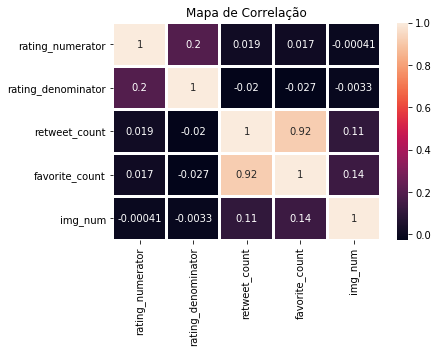

```python
c = df_twitter_archive_clean.corr()
sns.heatmap(c,
            xticklabels=c.columns.values,
            yticklabels=c.columns.values,annot=True, linewidths=2)
plt.title('Mapa de Correlação')
```

- Apenas 'retweet_count' e 'favorite_count' tem alguma correlação
- Numero de imagem nao influencia nas notas

```
Text(0,0.5,'Retweets')
```

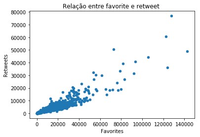

```python
df_twitter_archive_clean.plot(x = 'favorite_count' ,y ='retweet_count',kind = 'scatter')
plt.title('Relação entre favorite e retweet ')
plt.xlabel('Favorites')
plt.ylabel('Retweets')
```

- Confimando a correlação entre 'retweet_count' e 'favorite_count', mostrando ser uma correlação possitiva forte

```
Text(0.5,0,'Ano')
```

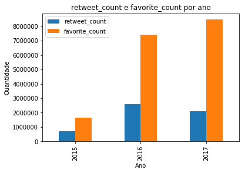

```python
df_twitter_archive_clean.groupby(df_twitter_archive_clean['timestamp'].dt.year)\
                                [['retweet_count','favorite_count']].sum().plot(kind= 'bar')
plt.title("retweet_count e favorite_count por ano")
plt.ylabel("Quantidade")
plt.xlabel("Ano")
```

- Apesar do melhor ano ser 2017, não teve muita diferença entre os anos de 2016 e 2017
- Aumente expressivo do ano 2015 para 2016
- Diminuição de retweet em 2017 em relação a 2016, porem aumento de favorite

```
Text(0.5,0,'Frquência')
```

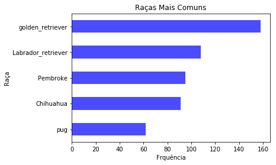

```python
df_twitter_archive_clean['dog_race'].value_counts(dropna= True)[1:6].sort_values().plot(kind = "barh", color = "blue",alpha = 0.7)
plt.title("Raças Mais Comuns")
plt.ylabel("Raça")
plt.xlabel("Frquência")
```

- Ainda tem muitas raças que o classificador não separou
- A raça mais comum é a Golden Retriver

```
Text(0.5,0,'Raça')
```

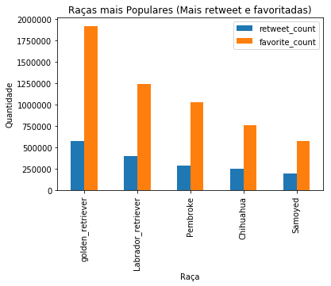

```python
df_twitter_archive_clean.groupby('dog_race')[['retweet_count','favorite_count']].sum().sort_values(by = 'retweet_count',ascending = False)[1:6].plot(kind = "bar")
plt.title("Raças mais Populares (Mais retweet e favoritadas)")
plt.ylabel("Quantidade")
plt.xlabel("Raça")
```

- Pode observar que os mais comuns tendem ser também os mais poulares

```
Text(0.5,0,'Frequência')
```

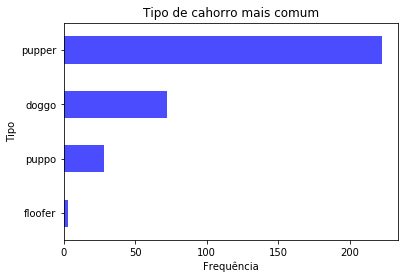

```python
df_twitter_archive_clean['dog_type'].value_counts(dropna = True)[0:10].sort_values().plot(kind = "barh", color = "blue",alpha = 0.7)
plt.title("Tipo de cahorro mais comum")
plt.ylabel("Tipo")
plt.xlabel("Frequência")
```

- Filhotes são os mais comumns e provavelmente mais populares